# Solution: Bird Species Activity

Matthew Beckman

```r
rm(list = ls())

library(tidyverse)
library(dcData)
```

# Set Up

```r
# Load the data set into our RStudio environment
data("OrdwayBirds")
data("OrdwaySpeciesNames")

# Inspect the data
str(OrdwayBirds)
```

```
'data.frame':   15829 obs. of  26 variables:
 $ bogus            : chr  "." "." "." "." ...
 $ Timestamp        : chr  "4/14/2010 13:20:56" "" "5/13/2010 16:00:30" "5/13/2010 16:02:15" ...
 $ Year             : chr  "1972" "" "1972" "1972" ...
 $ Day              : chr  "16" "" "16" "16" ...
 $ Month            : chr  "7" "" "7" "7" ...
 $ CaptureTime      : chr  "7:00:00" "" "7:00:00" "7:00:00" ...
 $ SpeciesName      : chr  "Song Sparrow" "" "Song Sparrow" "Field Sparrow" ...
 $ Sex              : chr  "U" "" "U" "U" ...
 $ Age              : chr  "AHY (After Hatch Year)" "" "AHY (After Hatch Year)" "AHY (After Hatch Year)" ...
 $ BandNumber       : chr  "107-151187" "" "107-151187" "1260-74572" ...
 $ TrapID           : chr  "warbler" "" "Warbler" "Warbler" ...
 $ Weather          : chr  "none" "" "none" "none" ...
 $ BandingReport    : chr  "check mark in record" "" "check mark in record" "no check mark in record" ...
 $ RecaptureYN      : chr  "no check" "" "no check" "check or yes" ...
 $ RecaptureMonth   : chr  "none" "" "none" "7" ...
 $ RecaptureDay     : chr  "none" "" "none" "9" ...
 $ Condition        : chr  "none" "" "none" "none" ...
 $ Release          : chr  "none" "" "none" "none" ...
 $ Comments         : chr  "none" "" "none" "none" ...
 $ DataEntryPerson  : chr  "Jerald Dosch" "Caitlin Baker" "Caitlin Baker" "Caitlin Baker" ...
 $ Weight           : chr  "" "" "" "" ...
 $ WingChord        : chr  "" "" "" "" ...
 $ Temperature      : chr  "" "" "" "" ...
 $ RecaptureOriginal: chr  "" "" "" "" ...
 $ RecapturePrevious: chr  "" "" "" "" ...
 $ TailLength       : chr  "" "" "" "" ...
```

# Activity

When you’re finished with this activity, you will have a graph that shows what time of year various species appear at the Katherine Ordway Natural History Study Area in Inver Grove Heights, MN.

### Step 0

```r
# Get the data table & clean up dates (see Data Computing p. 163)
OrdwayBirds <-
  OrdwayBirds %>%
  select(SpeciesName, Month, Day) %>%
  mutate(Month = as.numeric(as.character(Month)),
         Day = as.numeric(as.character(Day)))

# Inspect result
head(OrdwayBirds)
```

|  | SpeciesName | Month | Day |
| --- | --- | --- | --- |
| 3 | Song Sparrow | 7 | 16 |
| 4 |  | NA | NA |
| 5 | Song Sparrow | 7 | 16 |
| 6 | Field Sparrow | 7 | 16 |
| 7 | Field Sparrow | 7 | 16 |
| 8 | Song Sparrow | 7 | 16 |

### Step 1

There are 275 unique “species names” in the `OrdwayBirds` data if mis-spellings are counted among the unique entries, and 109 distinct species.

```r
# unique species in original data (including mis-spellings)
OrdwayBirds %>%
  summarise(uniqueNamesMisSpelled = n_distinct(SpeciesName))
```

| uniqueNamesMisSpelled |
| --- |
| 275 |

```r
# unique species in the clean list
OrdwaySpeciesNames %>%
  summarise(uniqueSpecies = n_distinct(SpeciesNameCleaned))
```

| uniqueSpecies |
| --- |
| 109 |

### Step 2

- The `inner_join()` uses the `SpeciesName` variable found in both data tables to match cases.
- The variables that were added to the `Corrected` table include a clean version of species names called `Species`, as well as the `Month` and `Day` of the bird sightings recorded.

```r
# inspect OrdwaySpeciesNames
str(OrdwaySpeciesNames)
```

```
'data.frame':   265 obs. of  2 variables:
 $ SpeciesName       : chr  "" "-lost-" "-missing-" "[Nothing, just dashes]" ...
 $ SpeciesNameCleaned: chr  NA NA NA NA ...
```

```r
# inner join
Corrected <-
  OrdwayBirds %>%
  inner_join(OrdwaySpeciesNames) %>%
  select(Species = SpeciesNameCleaned, Month, Day) %>%
  na.omit()  ## clened up missing names
# inspect the data after the join
head(Corrected)
```

|  | Species | Month | Day |
| --- | --- | --- | --- |
| 1 | Song Sparrow | 7 | 16 |
| 3 | Song Sparrow | 7 | 16 |
| 4 | Field Sparrow | 7 | 16 |
| 5 | Field Sparrow | 7 | 16 |
| 6 | Field Sparrow | 7 | 16 |
| 7 | Field Sparrow | 7 | 16 |

### Step 3

```r
# count sightings by species in descending order
SpeciesCount <-
  Corrected %>%
  group_by(Species) %>%
  summarise(count = n()) %>%
  arrange(desc(count))

# a hint on p.164 recommends displaying the top 10 species to choose our threshold
head(SpeciesCount, 10)
```

| Species | count |
| --- | --- |
| Slate-colored Junco | 2732 |
| Tree Swallow | 1537 |
| Black-capped Chickadee | 1327 |
| American Goldfinch | 1204 |
| Field Sparrow | 1164 |
| Lincoln's Sparrow | 790 |
| Robin | 608 |
| Catbird | 554 |
| Song Sparrow | 512 |
| House Wren | 460 |

```r
# create a sightings threshold that we will use to define the major species
threshold <- 750

Majors <-
  SpeciesCount %>%
  filter(count >= threshold)  # threshold is just a scalar defined above

Majors
```

| Species | count |
| --- | --- |
| Slate-colored Junco | 2732 |
| Tree Swallow | 1537 |
| Black-capped Chickadee | 1327 |
| American Goldfinch | 1204 |
| Field Sparrow | 1164 |
| Lincoln's Sparrow | 790 |

### Step 4

We now want to produce a month-by-month count for each of the major species, and then construct a chart to tell the story of what time of year the various species appear.

```r
ByMonth <-
  Majors %>%
  left_join(Corrected, by = "Species") %>%
  group_by(Month, Species) %>%
  summarise(count = n()) %>%
  arrange(Month, desc(count))
```

Now, using `esquisser()` in the console, we can configure a reasonable graph and choose “show expression” to get `ggplot2` that can be embedded in our report.

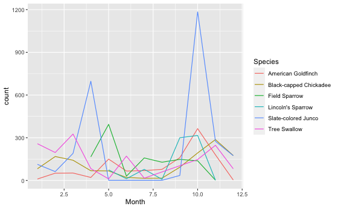

According to the graph, we can answer the questions posed:

##### 1. Which species are present year-round?

It appears that the American Goldfinch, and Black-capped Chickadee were sighted every month (though with fluctuation)

##### 2. Which species are migratory, that is, primarily present in one or two seasons?

(solutions vary) It appears that the Field Sparrow, Slate-colored Junco, and Lincoln’s Sparrow appear to be primarily present in one or two seasons and are likely migratory.

(solutions vary) If we set a threshold for “seen in good numbers” as 100 sightings in a month based on the graph (i.e. a little over 3 per day), then we might conclude that Field Sparrows, Slate-Colored Juncos, and Tree Swallows are seen “in good numbers” for at least 6 months of the year. A few lines of code can validate what we’re seeing visually in the graph:

```r
ByMonth %>%
  filter(count >= 100) %>%
  group_by(Species) %>%
  summarise(monthsPresent = n_distinct(Month)) %>%
  filter(monthsPresent >= 6)
```

| Species | monthsPresent |
| --- | --- |
| Field Sparrow | 6 |
| Slate-colored Junco | 6 |
| Tree Swallow | 6 |